# Assignement Week 08

Laurin Schaller

2023-04-28

# Downloading data and setup

```r
download.file("https://ethz-ins.org/content/mouse_mm38_hippocampus.peakCounts.SE.rds", "mouse_mm38_hippocampus.peakCounts.SE.rds")
```

```r
suppressPackageStartupMessages({
  library(epiwraps)
  library(motifmatchr)
  library(MotifDb)
  library(universalmotif)
  library(sechm)
  library(BiocParallel)
  library(ggplot2)
  library(chromVAR) # for motif accessibility estimation
  library(SummarizedExperiment) # data structure
  library(limma) # for statistical analysis
})
```

```
## See system.file("LICENSE", package="MotifDb") for use restrictions.
```

```r
# to control multithreading, unix users can use:
#register(MulticoreParam(4))
# for windows users, rather one of the following:
register(SerialParam())
# register(SnowParam(2))
```

# Reading data and data exploration

We can see that there are three data sets for each gender and both control and experiment conditions. These are the amount of aligned fragments per peak. Just like in the practical we can also denote this data with conditions.

```r
filename <- "mouse_mm38_hippocampus.peakCounts.SE.rds"
seData <- readRDS(filename)
seData
```

```
## class: RangedSummarizedExperiment
## dim: 20660 12
## metadata(0):
## assays(1): counts
## rownames: NULL
## rowData names(0):
## colnames(12): Control_female_GSM6041841.bam
##   Control_female_GSM6041842.bam ... FSS_male_GSM6041857.bam
##   FSS_male_GSM6041858.bam
## colData names(1): depth
```

```r
colnames(seData)
```

```
##  [1] "Control_female_GSM6041841.bam" "Control_female_GSM6041842.bam"
##  [3] "Control_female_GSM6041843.bam" "Control_male_GSM6041844.bam"
##  [5] "Control_male_GSM6041845.bam"   "Control_male_GSM6041846.bam"
##  [7] "FSS_female_GSM6041853.bam"     "FSS_female_GSM6041854.bam"
##  [9] "FSS_female_GSM6041855.bam"     "FSS_male_GSM6041856.bam"
## [11] "FSS_male_GSM6041857.bam"       "FSS_male_GSM6041858.bam"
```

```r
seData$condition <- c("CTRL","CTRL","CTRL", "CTRL","CTRL","CTRL", "FSS", "FSS", "FSS", "FSS", "FSS", "FSS")
seData$condition
```

```
##  [1] "CTRL" "CTRL" "CTRL" "CTRL" "CTRL" "CTRL" "FSS"  "FSS"  "FSS"  "FSS"
## [11] "FSS"  "FSS"
```

```r
colData(seData)
```

```
## DataFrame with 12 rows and 2 columns
##                                   depth   condition
##                               <numeric> <character>
## Control_female_GSM6041841.bam  73170149        CTRL
## Control_female_GSM6041842.bam  93995034        CTRL
## Control_female_GSM6041843.bam  40167775        CTRL
## Control_male_GSM6041844.bam    70491005        CTRL
## Control_male_GSM6041845.bam    84985977        CTRL
## ...                                 ...         ...
## FSS_female_GSM6041854.bam      73674456         FSS
## FSS_female_GSM6041855.bam      49285912         FSS
## FSS_male_GSM6041856.bam        82385764         FSS
## FSS_male_GSM6041857.bam        68623011         FSS
## FSS_male_GSM6041858.bam        81801232         FSS
```

# Get the database of motifs

Last assignment I had used a lot of motif data from Jaspar so lets see what would happen if we used **JASPAR_CORE** instead. It creates a MotifList of only 47 entries. This is less than the hocomoco database. So it is not as extensive.

```r
motifs <- query(MotifDb, c("JASPAR_CORE", "mus"))
length(motifs)
```

```
## [1] 47
```

```r
motifs <- query(MotifDb, c("HOCOMOCOv11-core", "Hsapiens"))
length(motifs)
```

```
## [1] 400
```

```r
motifs <- do.call(TFBSTools::PWMatrixList, setNames(
           universalmotif::convert_motifs(motifs, class="TFBSTools-PWMatrix"),
           mcols(motifs)$geneSymbol))
```

#Reference genome Loading the mouse GRCm38 reference genome from the week 06 practical. This created a DNASringSet which is quite large at 3GB. Not sure if there is a more resourceful way of loading it.

```r
library(AnnotationHub)
library(Biostrings)
ah <- AnnotationHub(localHub=TRUE)
```

```
## Using 'localHub=TRUE'
##   If offline, please also see BiocManager vignette section on offline use
```

```
## snapshotDate(): 2023-04-06
```

```r
genome <- ah[["AH68356"]]
```

```
## loading from cache
```

```
## require("rtracklayer")
```

```r
genomeSeq <- Biostrings::getSeq(genome)
tail(genomeSeq)
```

```
## DNAStringSet object of length 6:
##     width seq                                               names
## [1] 23158 CATAAAACATTTTGTGCAATCTC...ATCAAAAGATGGCCTAGTCGGCC GL456382.1
## [2] 22974 CTGCTGCTTGCTATGGCTGGTAA...AGCAACCCTGACCTGCTCCCGTG GL456359.1
## [3] 21240 TCCTTGGGGGGCATACGCCCAGA...GAAAATGAGACACAAACACTGTA GL456396.1
## [4] 20208 GAAGGAAGGAAGGAAGGAAGGAA...ACTCTGTTGCAGGCTGCCTTCCA GL456368.1
## [5] 14945 GTGTGTGTGTGTGTGTGTGTGTG...GCCCGAGAGGTTTCTGCCTCAGG JH584292.1
## [6]  1976 GGCTGAGCGGTGACATCATGGGC...ACCGCACTGGGCAGAAGCCCGTG JH584295.1
```

# Adding GC bias, find motifs within peaks, calculating deviations

We can see that the motifmatchr gives us an object with our 20660 peaks and the 400 motifs we have retrieved from the motifDB. The deviations data has a dimension of 400x12 which corresponds to our 6 controls and 6 expierment conditions.

```r
seData <- chromVAR::addGCBias(seData, genome=genomeSeq)
moi <- motifmatchr::matchMotifs(motifs, subject=seData, genome=genomeSeq)
moi
```

```
## class: RangedSummarizedExperiment
## dim: 20660 400
## metadata(0):
## assays(1): motifMatches
## rownames: NULL
## rowData names(1): bias
## colnames(400): AHR AIRE ... ZNF8 ZSC22
## colData names(1): name
```

```r
dev <- chromVAR::computeDeviations(object = seData, annotations=moi,
                                   background_peaks=getBackgroundPeaks(seData, niterations=1000))
dev
```

```
## class: chromVARDeviations
## dim: 400 12
## metadata(0):
## assays(2): deviations z
## rownames(400): AHR AIRE ... ZNF8 ZSC22
## rowData names(3): name fractionMatches fractionBackgroundOverlap
## colnames(12): Control_female_GSM6041841.bam
##   Control_female_GSM6041842.bam ... FSS_male_GSM6041857.bam
##   FSS_male_GSM6041858.bam
## colData names(2): depth condition
```

```r
colData(dev)
```

```
## DataFrame with 12 rows and 2 columns
##                                   depth   condition
##                               <numeric> <character>
## Control_female_GSM6041841.bam  73170149        CTRL
## Control_female_GSM6041842.bam  93995034        CTRL
## Control_female_GSM6041843.bam  40167775        CTRL
## Control_male_GSM6041844.bam    70491005        CTRL
## Control_male_GSM6041845.bam    84985977        CTRL
## ...                                 ...         ...
## FSS_female_GSM6041854.bam      73674456         FSS
## FSS_female_GSM6041855.bam      49285912         FSS
## FSS_male_GSM6041856.bam        82385764         FSS
## FSS_male_GSM6041857.bam        68623011         FSS
## FSS_male_GSM6041858.bam        81801232         FSS
```

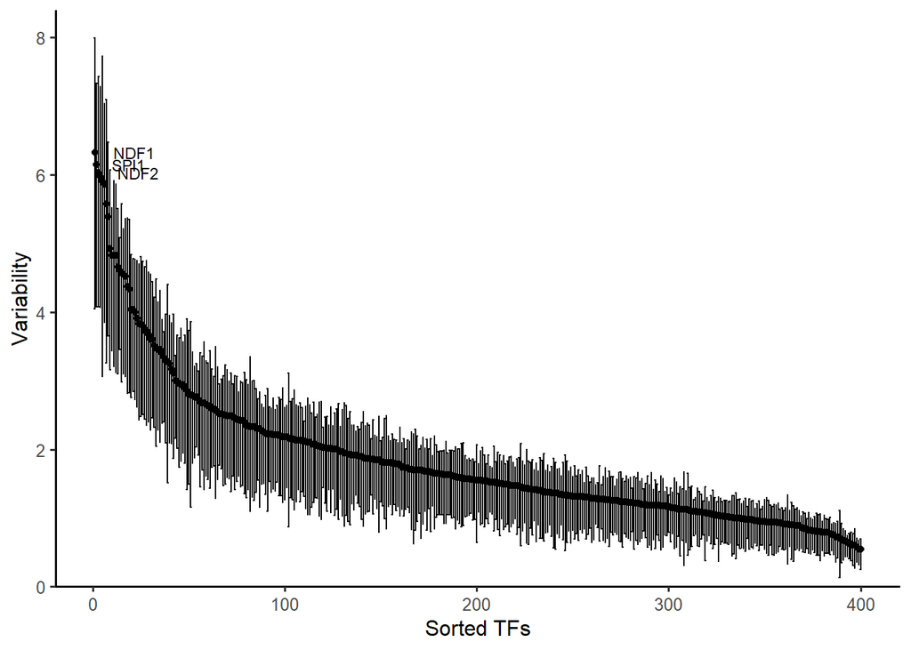

```r
variability <- computeVariability(dev)
plotVariability(variability)
```

# Normalization and deviation data

```r
head(assays(dev)$z)
```

```
##      Control_female_GSM6041841.bam Control_female_GSM6041842.bam
## AHR                    -0.53318748                     0.2376392
## AIRE                    0.01546915                    -0.3570130
## ALX1                    0.62129708                     0.1634217
## ANDR                    1.26333805                    -2.1137301
## AP2A                    2.46133191                    -0.4844227
## AP2B                    1.97421367                    -0.5148025
##      Control_female_GSM6041843.bam Control_male_GSM6041844.bam
## AHR                      0.3955725                  -0.3295832
## AIRE                    -2.4960577                   1.9820755
## ALX1                    -0.2441834                  -0.3158841
## ANDR                    -0.8105957                   2.2036111
## AP2A                    -2.0661533                   3.1132369
## AP2B                    -1.1307058                   1.7187228
##      Control_male_GSM6041845.bam Control_male_GSM6041846.bam
## AHR                   0.55365039                  -0.6437014
## AIRE                 -0.05604875                  -0.2686051
## ALX1                  0.47178010                  -1.2370129
## ANDR                 -1.23425594                   0.4745921
## AP2A                  0.92344687                   2.5824108
## AP2B                 -1.13768367                   0.6270042
##      FSS_female_GSM6041853.bam FSS_female_GSM6041854.bam
## AHR                  0.8752141                -0.2833365
## AIRE                 1.0161948                 1.3712448
## ALX1                -0.6627420                 0.8299286
## ANDR                 2.6251967                -1.0775753
## AP2A                 1.6534682                -3.1504833
## AP2B                 0.8614236                -0.3035732
##      FSS_female_GSM6041855.bam FSS_male_GSM6041856.bam FSS_male_GSM6041857.bam
## AHR                 -1.2577761              -1.0156808               0.5563953
## AIRE                 0.7960089               1.7970896               1.4840907
## ALX1                 0.1819910               0.7331702              -0.3054772
## ANDR                 2.1321596               0.3050284               3.2608366
## AP2A                 2.1614903               1.7822084               0.8916964
## AP2B                 0.2827041               1.5379642               0.9604007
##      FSS_male_GSM6041858.bam
## AHR              -0.05827377
## AIRE              0.26380696
## ALX1             -0.35230272
## ANDR             -1.51032032
## AP2A              0.06472036
## AP2B             -0.62850659
```

```r
assays(dev)$norm <- scale(assays(dev)$z)
dev
```

```
## class: chromVARDeviations
## dim: 400 12
## metadata(0):
## assays(3): deviations z norm
## rownames(400): AHR AIRE ... ZNF8 ZSC22
## rowData names(3): name fractionMatches fractionBackgroundOverlap
## colnames(12): Control_female_GSM6041841.bam
##   Control_female_GSM6041842.bam ... FSS_male_GSM6041857.bam
##   FSS_male_GSM6041858.bam
## colData names(2): depth condition
```

```r
dev$condition
```

```
##  [1] "CTRL" "CTRL" "CTRL" "CTRL" "CTRL" "CTRL" "FSS"  "FSS"  "FSS"  "FSS"
## [11] "FSS"  "FSS"
```

```r
head(deviations(dev))
```

```
##      Control_female_GSM6041841.bam Control_female_GSM6041842.bam
## AHR                  -0.0185603421                   0.009456521
## AIRE                  0.0002978418                  -0.007733366
## ALX1                  0.0126310326                   0.004508457
## ANDR                  0.0125753750                  -0.026132419
## AP2A                  0.0256187456                  -0.005393384
## AP2B                  0.0195722734                  -0.005520812
##      Control_female_GSM6041843.bam Control_male_GSM6041844.bam
## AHR                     0.09873342                -0.013619807
## AIRE                   -0.30965514                 0.047225520
## ALX1                   -0.03543701                -0.008334234
## ANDR                   -0.05355054                 0.027507264
## AP2A                   -0.14610396                 0.042607990
## AP2B                   -0.07620869                 0.022780338
##      Control_male_GSM6041845.bam Control_male_GSM6041846.bam
## AHR                  0.027297967                -0.026884245
## AIRE                -0.001291118                -0.005494868
## ALX1                 0.011569165                -0.029403794
## ANDR                -0.014861049                 0.005214621
## AP2A                 0.013356588                 0.030371151
## AP2B                -0.015960286                 0.006702669
##      FSS_female_GSM6041853.bam FSS_female_GSM6041854.bam
## AHR                0.038190401              -0.024307396
## AIRE               0.022125403               0.062567763
## ALX1              -0.017002271               0.044080890
## ANDR               0.029943690              -0.025425009
## AP2A               0.019948998              -0.073741100
## AP2B               0.009163243              -0.007105758
##      FSS_female_GSM6041855.bam FSS_male_GSM6041856.bam FSS_male_GSM6041857.bam
## AHR               -0.054844942             -0.03132318              0.02754322
## AIRE               0.014067998              0.03054970              0.03093804
## ALX1               0.003802848              0.01537793             -0.00739272
## ANDR               0.020422784              0.00280688              0.03687613
## AP2A               0.021049070              0.01731465              0.01083048
## AP2B               0.002846029              0.01386832              0.01161107
##      FSS_male_GSM6041858.bam
## AHR            -0.0018735233
## AIRE            0.0046616111
## ALX1           -0.0065989323
## ANDR           -0.0137843914
## AP2A            0.0006849675
## AP2B           -0.0056472850
```

# Different conditions based on control vs. healthy + female vs. male

```r
#dev$condition <- c("CTRL","CTRL","CTRL", "CTRL","CTRL","CTRL", "FSS", "FSS", "FSS", "FSS", "FSS", "FSS")
dev$condition <- factor(dev$condition)
dev$condition <- relevel(dev$condition, c("CTRL"))
dev$condition
```

```
##  [1] CTRL CTRL CTRL CTRL CTRL CTRL FSS  FSS  FSS  FSS  FSS  FSS
## Levels: CTRL FSS
```

```r
mm <- model.matrix(~dev$condition)
mm
```

```
##    (Intercept) dev$conditionFSS
## 1            1                0
## 2            1                0
## 3            1                0
## 4            1                0
## 5            1                0
## 6            1                0
## 7            1                1
## 8            1                1
## 9            1                1
## 10           1                1
## 11           1                1
## 12           1                1
## attr(,"assign")
## [1] 0 1
## attr(,"contrasts")
## attr(,"contrasts")$`dev$condition`
## [1] "contr.treatment"
```

# Fit exploration and volcano plot

```r
fit <- eBayes(lmFit(assays(dev)$norm, mm))
order(fit$F.p.value)
```

```
##   [1] 106 251 172 170  27 160 270 173 306 187 253 313 178 180 370   2  95  94
##  [19]  87  16 222 217 188  90  93 179  35 234 395 324 314 171 279 196 274 280
##  [37]  65  34 210 215 264 240 312 169  96 237  97  86 223  10 294  98  49 377
##  [55] 227 352 126 246 386 147 208 159 369 142  85 242 236 360 303  84  69  42
##  [73]  23 182 139 198 232  41 328 332 209  68 103 376 252  20 302 122 378 315
##  [91] 263 394 155 320  19 213 354 228 397   5 277 311 351 135 216 143 105 184
## [109] 299 275  11 298 273 206 389 372  43  45 107 132 136 304 257 197 337 323
## [127] 108  88 373 175 318 363 120  91  26  62  92  39 181 346 393 134 356 235
## [145]   7 109 286 247 127 111 225 398 271 391 131  51 349  99 104 183  22 357
## [163] 327 300 212   4 152  63 284  66  31 256 158 380 238  67  75 148 291 301
## [181]  38 272   8 199   9 310 114  74  44 166  37 113 250 224 156 255  14 309
## [199] 249 368  21 117  17 193 140 230  77  52  32  60 115 226 174 129 307 220
## [217]  54 400 128  82 157  79 219  64 192  73  55 387  71 375 163 316 305  12
## [235]  57 211 342 177   1 137 146  70  80 118  53  81  89 333 102 191  56 338
## [253] 221 345 261  83 339 269 138  28 123 382 353 141 239  59 243 189 130  24
## [271] 254 145 343 176 390 278 292  33 100 276 283  46 268 207 295 285 162 297
## [289] 317 144 336 340 350   6 289 385 218 347  36 125 110 121 341 366 326 186
## [307] 101  58 358 388 229 321 293 190 359 201 194  50 267 233  72 168  48 116
## [325] 335 322 149 319  25 167 371 355   3 334 133 362  61 204 282 195 331 260
## [343] 392 296 124  76 150 330 259  78 308 244 329 287 361 367  30 383 384 379
## [361] 185 245 396 153 281 365  40 381 348  29  13 161 399 241 214 119 202  47
## [379] 203 265 290 112 344 262 164 266 374 364 154 151  18  15 205 165 258 200
## [397] 288 325 248 231
```

```r
fit$F.p.value[106]
```

```
## [1] 0.0001975612
```

```r
fit$F.p.value[251]
```

```
## [1] 0.0003312459
```

```r
fit$F.p.value[172]
```

```
## [1] 0.06675796
```

```r
res <- as.data.frame(topTable(fit, number = Inf))
```

```
## Removing intercept from test coefficients
```

```r
head(res)
```

```
##            logFC     AveExpr         t      P.Value adj.P.Val         B
## GCR    4.4158739  0.23761175  5.712518 5.082222e-05 0.0183548  2.178796
## PRGR   3.5734508  0.27936798  5.384004 9.177401e-05 0.0183548  1.641820
## MEF2C -1.1852307 -0.12940420 -2.507998 2.487489e-02 0.9989319 -3.514354
## MEF2A -0.9423904 -0.06381137 -2.164342 4.795166e-02 0.9989319 -4.097110
## CDX1   0.8426437  0.03776712  2.156024 4.870410e-02 0.9989319 -4.110746
## MEF2D -1.1083904 -0.06964231 -2.110954 5.297539e-02 0.9989319 -4.184192
```

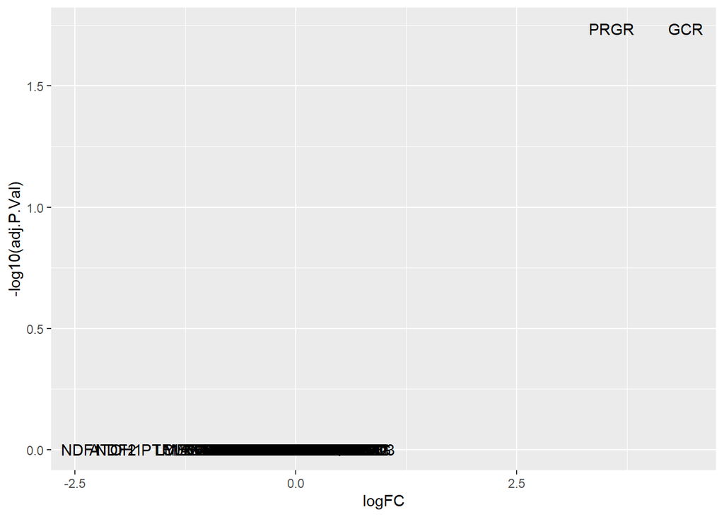

```r
res$TF <- row.names(res)
ggplot(res, aes(logFC, -log10(adj.P.Val), label=TF)) + geom_text()
```

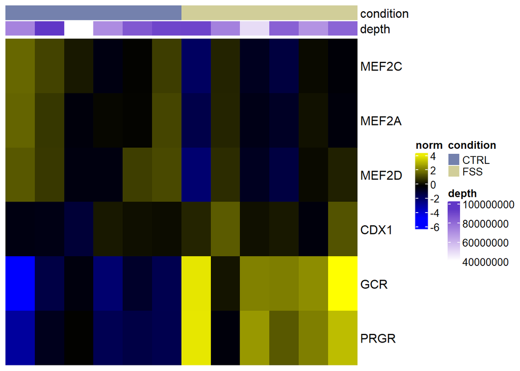

```r
sechm(dev, features = head(row.names(res)), assayName="norm", top_annotation = c("condition", "depth"))
```

# Adding gender information to graph

```r
dev$gender <- c("FEMALE","FEMALE","FEMALE", "MALE","MALE","MALE", "FEMALE", "FEMALE", "FEMALE", "MALE", "MALE", "MALE")
dev$gender <- factor(dev$gender)
dev$gender <- relevel(dev$gender, c("FEMALE"))
dev$gender
```

```
##  [1] FEMALE FEMALE FEMALE MALE   MALE   MALE   FEMALE FEMALE FEMALE MALE
## [11] MALE   MALE
## Levels: FEMALE MALE
```

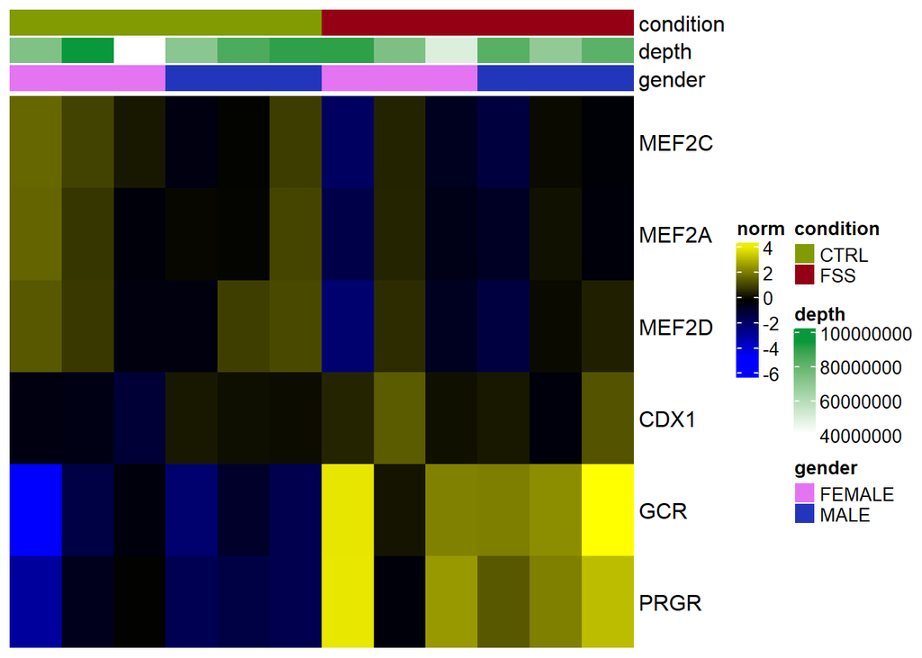

```r
sechm(dev, features = head(row.names(res)), assayName="norm", top_annotation = c("condition", "depth", "gender"))
```

# New model but for gender differences We have to be careful now as there are 3 female controls, 3 male controls, 3 female experiment conditions and then 3 male experiment conditions. But this looks right.

```r
mm2 <- model.matrix(~dev$gender)
mm2
```

```
##    (Intercept) dev$genderMALE
## 1            1              0
## 2            1              0
## 3            1              0
## 4            1              1
## 5            1              1
## 6            1              1
## 7            1              0
## 8            1              0
## 9            1              0
## 10           1              1
## 11           1              1
## 12           1              1
## attr(,"assign")
## [1] 0 1
## attr(,"contrasts")
## attr(,"contrasts")$`dev$gender`
## [1] "contr.treatment"
```

```r
fit2 <- eBayes(lmFit(assays(dev)$norm, mm2))
order(fit2$F.p.value)
```

```
##   [1] 345 329 335 374 325 334 400  55  50  47 307 392  54 151 322 319 327 154
##  [19] 292 293 371 138  56 259 337 265  13  21 393 196 267 289 262  53 310 362
##  [37] 290 175 163 140  59 333 197 330 210 382 266 218 321  60 141 132 224  43
##  [55] 300 149 176 379 346 167 338 291  75  64  57 135 242 361 324 299 257 136
##  [73] 331   8  58 303 364 253   7 100 212 128 398 126 311 130 204 368  11 377
##  [91]  85  61 211  25 320 198 301 328 260  88 261  10 137  70 153   5 315  42
## [109] 150 105 217  35  74 208 305 249 302  24  49 219 258  22 179 256 298 178
## [127] 263 162 247 347 359 354 183 395 121 252 385 264 235  65 295  12  73 365
## [145]  44 357 236 389 155 355  94  40 240  38 246 104  32 103 304  66 117 245
## [163] 237  93 280 227 230 277 225 274  52 268 234  79 168  90 271  31 358 356
## [181] 122  39  37 152  41 133 203  48 373 180  84  26  45 216 332 370 184 222
## [199] 243 110 294 287 193 367 107 254 123  98 213 314 340 238 165 220 372 157
## [217] 139 191 116  76  95  36  92 232 205 309   2 159 127 148 109 199 313  51
## [235]  78  87 233 111 160 215 336 323 390 272 209  82 164 158 351 244   3 255
## [253] 166 182 281  46  23 120 226  19  97 113 275 125  28 349 383 228 221 187
## [271] 115  29  99   1  86 363  69 143 192 276  16  81 282  71 134  20 229 188
## [289] 312 316 279 273  62 169  34 391 172  15 185 375 223 181 118 146  80 177
## [307] 278 387 396 343  33   9  18 250  83 248  14 147 156  91 174 231 308 284
## [325] 241 360  27 269  89 348 239 190 386 342 270  77 106 142 186 171 306 317
## [343] 145 394 207 161 114 201 189 101 353 206 296 194 378 286 326 144 124 102
## [361]   6 350  72   4 397 352 251  68 339  17 318 380  63 173  67  30 369 288
## [379] 285 170 195 202 366 283 381 131 376 341 384 119 214 388 112 297  96 344
## [397] 108 200 129 399
```

```r
fit2$F.p.value[345]
```

```
## [1] 1.004355e-07
```

```r
fit2$F.p.value[329]
```

```
## [1] 8.110051e-07
```

```r
fit2$F.p.value[335]
```

```
## [1] 2.046465e-05
```

```r
fit2$F.p.value[fit2$F.p.value < 0.05]
```

```
##  [1] 1.448737e-02 1.458731e-02 3.626018e-03 2.683884e-03 2.183095e-02
##  [6] 4.781806e-03 1.337983e-03 1.309192e-02 3.351437e-02 1.120047e-02
## [11] 3.216679e-02 5.424023e-03 6.635245e-03 3.200562e-02 3.085813e-02
## [16] 1.857287e-02 3.552680e-02 4.170880e-02 4.444705e-02 1.309655e-02
## [21] 2.074189e-02 1.437967e-02 4.250657e-02 1.917185e-02 2.019702e-02
## [26] 2.882603e-02 8.194551e-03 9.434505e-03 3.849107e-03 2.601105e-02
## [31] 6.292692e-03 4.546752e-02 6.222113e-03 3.656500e-05 6.616168e-03
## [36] 8.110051e-07 3.985202e-02 3.537670e-02 4.973896e-04 2.046465e-05
## [41] 1.342882e-02 1.004355e-07 2.846880e-02 9.707294e-03 2.184343e-05
## [46] 4.246277e-02 4.520803e-03 1.565070e-02 5.494598e-04
```

```r
res2 <- as.data.frame(topTable(fit2, number = Inf))
```

```
## Removing intercept from test coefficients
```

```r
head(res2)
```

```
##           logFC     AveExpr          t      P.Value    adj.P.Val        B
## ZFP42 -4.510351 -0.41652190 -10.793611 2.708010e-08 1.083204e-05 9.440124
## TYY1  -4.543573 -0.23820656  -9.251397 1.917980e-07 3.835961e-05 7.579280
## Z324A -2.229107 -0.05132674  -7.069008 4.774157e-06 5.097525e-04 4.441478
## ZN384 -2.954838 -0.06587164  -7.028350 5.097525e-06 5.097525e-04 4.376748
## THAP1 -2.225209  0.03063427  -6.712050 8.552222e-06 6.841778e-04 3.864935
## WT1   -1.919026 -0.11928198  -5.156806 1.329191e-04 8.861272e-03 1.137231
```

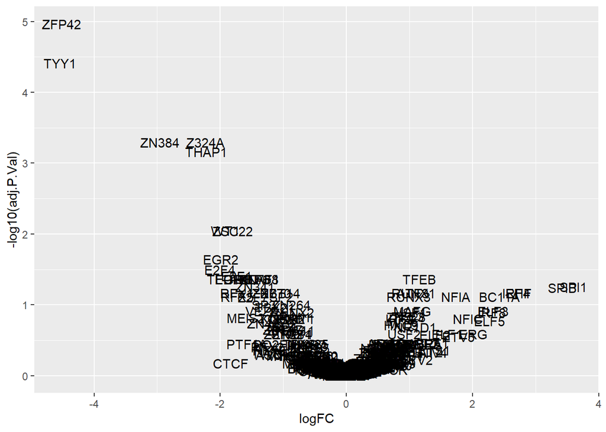

```r
res2$TF <- row.names(res2)
ggplot(res2, aes(logFC, -log10(adj.P.Val), label=TF)) + geom_text()
```

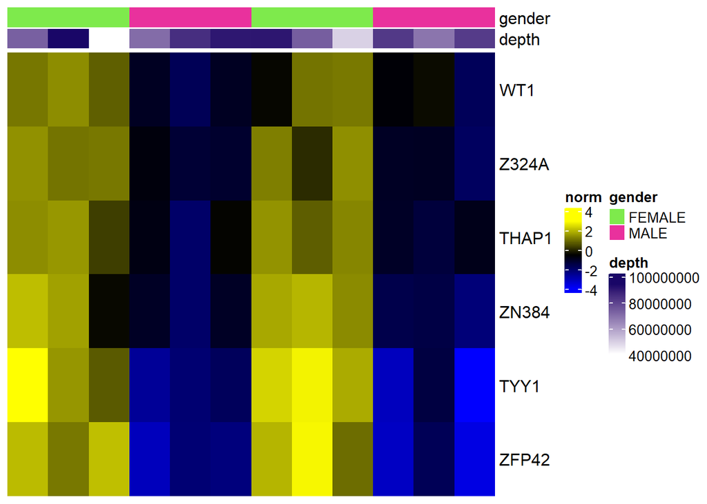

```r
sechm(dev, features = head(row.names(res2)), assayName="norm", top_annotation = c("gender", "depth"))
```